# DeepLearning_Assignment1_Ajinkya

```python
import tensorflow as tf
import tensorflow_datasets as tfds
import numpy as np
from matplotlib import pyplot as plt
from keras.models import Model
from sklearn.decomposition import PCA
import random
import keras
from keras import backend as K
import pandas as pd
from sklearn.manifold import TSNE
from keras.models import Sequential
from keras.layers.core import Dense,Activation
```

```python
print("Num GPUs Available: ", len(tf.config.list_physical_devices('GPU')))
```

```
Num GPUs Available:  1
```

**Part 1**

```python
mnist = tf.keras.datasets.mnist
  (xtrain, ytrain), (xtest,ytest) = mnist.load_data()
```

```
Downloading data from https://storage.googleapis.com/tensorflow/tf-keras-datasets/mnist.npz
```

```python
xtest.shape
```

[output not shown]

```python
xtrain = np.reshape(xtrain, [-1, 784])
xtest = np.reshape(xtest, [-1, 784])
xtrain, xtest = xtrain/255, xtest/255
```

```python
ytest
```

```
array([7, 2, 1, ..., 4, 5, 6], dtype=uint8)
```

```python
baseline = Sequential()
baseline.add(Dense(1024, input_dim=784))
baseline.add(Activation('relu'))
baseline.add(Dense(1024))
baseline.add(Activation('relu'))
baseline.add(Dense(1024))
baseline.add(Activation('relu'))
baseline.add(Dense(1024))
baseline.add(Activation('relu'))
baseline.add(Dense(1024))
baseline.add(Activation('relu'))
baseline.add(Dense(10))
baseline.add(Activation('softmax'))
```

```python
baseline.summary()
```

```
Model: "sequential"
_________________________________________________________________
Layer (type)                 Output Shape              Param #
=================================================================
dense (Dense)                (None, 1024)              803840
_________________________________________________________________
activation (Activation)      (None, 1024)              0
_________________________________________________________________
dense_1 (Dense)              (None, 1024)              1049600
_________________________________________________________________
activation_1 (Activation)    (None, 1024)              0
_________________________________________________________________
dense_2 (Dense)              (None, 1024)              1049600
_________________________________________________________________
activation_2 (Activation)    (None, 1024)              0
_________________________________________________________________
dense_3 (Dense)              (None, 1024)              1049600
_________________________________________________________________
activation_3 (Activation)    (None, 1024)              0
_________________________________________________________________
dense_4 (Dense)              (None, 1024)              1049600
_________________________________________________________________
activation_4 (Activation)    (None, 1024)              0
_________________________________________________________________
dense_5 (Dense)              (None, 10)                10250
_________________________________________________________________
activation_5 (Activation)    (None, 10)                0
=================================================================
Total params: 5,012,490
Trainable params: 5,012,490
Non-trainable params: 0
_________________________________________________________________
```

```python
baseline.compile(optimizer='adam',loss='sparse_categorical_crossentropy',metrics=['accuracy'])
```

```python
baseline.fit(xtrain,ytrain,epochs=15)
```

```
<keras.callbacks.History at 0x7f7f8e0cbd10>
```

As you can see the test accuracy reaches more than 98 % for the baseline model.

```python
baseline.evaluate(xtest,ytest)
```

```
[0.14924754202365875, 0.98089998960495]
```

```python
xtest_sam = xtest[np.random.choice(xtest.shape[0], size=1000, replace = False), :]
```

```python
xtest.shape
```

```
(10000, 784)
```

```python
predictions = baseline.predict(xtest_sam)
```

```python
predictions[0]
```

```
array([2.6757203e-07, 2.4745686e-05, 9.7220967e-04, 1.2601145e-04,
       1.7160004e-05, 1.7066959e-07, 4.5715516e-09, 9.9771357e-01,
       3.2419842e-07, 1.1455565e-03], dtype=float32)
```

```python
predictions.shape
```

```
(1000, 10)
```

```python
final=[]
for i in range(len(predictions)):
  final.append([i,np.argmax(predictions[i]),max(predictions[i])])
```

```python
final[0:10]
```

```
[[0, 7, 0.99771357],
 [1, 6, 0.9223595],
 [2, 3, 1.0],
 [3, 3, 1.0],
 [4, 3, 1.0],
 [5, 8, 0.99976844],
 [6, 2, 1.0],
 [7, 0, 0.9999995],
 [8, 2, 1.0],
 [9, 0, 1.0]]
```

```python
findex=[]
for i in range(0,10):
  final_sub = list(filter(lambda x:x[1]==i,final))
  final_sub = list(sorted(final_sub, key = lambda x: x[2], reverse=True))
  #final_0[:10]
  findex.append([item[0] for item in final_sub[:10]])
```

```python
findex
```

```
[[9, 23, 45, 102, 136, 142, 146, 155, 161, 195],
 [10, 20, 28, 32, 33, 43, 50, 58, 61, 66],
 [6, 8, 25, 29, 42, 57, 68, 78, 79, 105],
 [2, 3, 4, 12, 15, 27, 39, 53, 64, 65],
 [31, 37, 77, 111, 112, 117, 122, 152, 153, 158],
 [13, 17, 44, 52, 54, 59, 60, 63, 71, 73],
 [11, 46, 47, 86, 87, 91, 95, 149, 150, 156],
 [16, 56, 75, 89, 98, 124, 137, 139, 144, 165],
 [22, 26, 48, 51, 92, 106, 114, 119, 123, 129],
 [34, 67, 69, 104, 107, 211, 214, 363, 375, 378]]
```

Plotting the images 10 x 10 subplot for the last layer output. Argmax is taken and the top 10 probabilites for each digit is displayed.

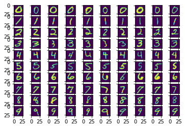

```python
# Ref: https://stackoverflow.com/questions/53837545/plotting-mnist-samples
fig, axis = plt.subplots(10, 10, sharex='col', sharey='row')
for i in range(10):
    for j in range(10):
        axis[i,j].imshow(np.reshape(xtest_sam[findex[i][j]],(28,28)))
```

Getting the output of the 2nd last layer

```python
# Ref: https://stackoverflow.com/questions/41711190/keras-how-to-get-the-output-of-each-layer
layer_name = 'dense_4'
intermediate_layer_model = Model(inputs=baseline.input,
                                 outputs=baseline.get_layer(layer_name).output)
intermediate_output = intermediate_layer_model.predict(xtest_sam)
```

```python
intermediate_output.shape
```

```
(1000, 1024)
```

```python
intermediate_output
```

```
array([[ -4.8754983,  -5.204884 ,  -4.1364903, ...,  -4.025049 ,
         -3.0151825,  -5.616513 ],
       [ -4.3857656,  -8.315462 ,  -7.369806 , ...,  -0.7683243,
         -4.0979567,  -5.7315764],
       [ -8.31882  , -30.570902 , -19.348043 , ..., -15.003793 ,
        -11.431576 , -16.88477  ],
       ...,
       [ -1.9071581,  -4.7194314,  -4.525356 , ...,  -1.6687231,
         -2.569554 ,  -4.891182 ],
       [-10.116842 ,  -9.836069 ,  -8.674841 , ...,  -7.483243 ,
         -6.145269 , -10.718211 ],
       [-10.842068 , -10.633439 ,  -9.474473 , ...,  -8.09189  ,
         -6.7257724, -11.429615 ]], dtype=float32)
```

```python
intermediate_output[1]
```

```
array([-4.3857656, -8.315462 , -7.369806 , ..., -0.7683243, -4.0979567,
       -5.7315764], dtype=float32)
```

Selecting 10 random dimensions from 1024

```python
c = random.sample(range(1024),10)
print(c)
intermidiate_output_10 = intermediate_output[:,c]
```

```
[145, 204, 1020, 392, 607, 186, 990, 81, 43, 800]
```

```python
intermidiate_output_10.shape
```

```
(1000, 10)
```

```python
final=[]
for i in range(len(intermidiate_output_10)):
  final.append([i,np.argmax(intermidiate_output_10[i]),max(intermidiate_output_10[i])])
```

```python
findex=[]
for i in range(0,10):
  final_sub = list(filter(lambda x:x[1]==i,final))
  final_sub = list(sorted(final_sub, key = lambda x: x[2], reverse=True))
  #final_0[:10]
  findex.append([item[0] for item in final_sub[:10]])
```

```python
findex
```

```
[[972, 537, 247, 59, 752, 813, 100, 695, 905, 54],
 [363, 107],
 [843, 42, 722, 665, 133, 570, 6, 502, 903, 557],
 [548, 238, 746, 449, 879, 825, 583, 240, 352, 789],
 [928, 360],
 [],
 [193, 125, 986, 713, 446, 224, 27, 881, 269, 305],
 [],
 [],
 []]
```

Plotting the images 10 x 10 subplot for the second last layer output. Argmax is taken and the top 10 probabilites for each digit is displayed.The reason certain digits are missing is because the second last layer extracts features for only specific digits and not all as in the earlier 10 x 10 plot, that's the reason we are getting plots with missing spaces. Also, the dimension was 1024 out of which we selected 10 random dimensions for the experiment, which also makes a difference.

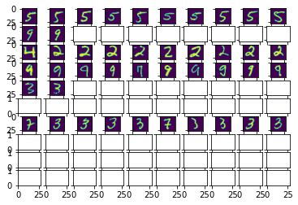

```python
# Ref: https://stackoverflow.com/questions/53837545/plotting-mnist-samples
fig, axis = plt.subplots(10, 10, sharex='col', sharey='row')
for i in range(10):
    for j in range(10):
        if findex[i] ==[] or j > len(findex[i])-1:
          continue
        axis[i,j].imshow(np.reshape(xtest_sam[findex[i][j]],(28,28)))
```

```python
from google.colab import drive
drive.mount('/content/drive')
```

PCA and tSNEPlots

```python
c = random.sample(range(10000),1000)
xtest_flat = xtest[c]
ytest_flat = ytest[c]
```

```python
xtest_flat.shape
```

```
(1000, 784)
```

```python
ytest_flat.shape
```

```
(1000,)
```

PCA and tSNE for the raw iamges

```python
pca_dim = PCA(n_components=2)
xtest_pca = pca_dim.fit_transform(xtest_flat)
principal_df = pd.DataFrame(data = xtest_pca, columns = ['PCA 1', 'PCA 2'])
```

```python
unames, id, count = np.unique(ytest_flat, return_inverse=True, return_counts=True)
sum_pca_0 = np.bincount(id, weights=xtest_pca[:, 0])
sum_pca_1= np.bincount(id, weights=xtest_pca[:, 1])
mean_pca_0 = sum_pca_0 /count
mean_pca_1 = sum_pca_1 /count
```

The raw images in PCA are little difficult to classify because there are some overlappings, but still you can see different clusters overall.

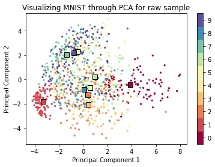

```python
plt.scatter(xtest_pca[:, 0], xtest_pca[:, 1], s= 5, c=ytest_flat, cmap='Spectral')
plt.scatter(mean_pca_0,mean_pca_1,c=unames,cmap='Spectral',marker ="s", edgecolor ="black", s = 70)
plt.rcParams["figure.figsize"] = (15,5)
plt.gca().set_aspect('equal', 'datalim')
plt.colorbar(boundaries=np.arange(11)-0.5).set_ticks(np.arange(10))
plt.title('Visualizing MNIST through PCA for raw sample', fontsize=12);
plt.xlabel('Principal Component 1')
plt.ylabel('Principal Component 2')
```

```python
tsne = TSNE(n_components=2, random_state=0)
xtest_tsne= tsne.fit_transform(xtest_flat)
```

```python
unames, id, count = np.unique(ytest_flat, return_inverse=True, return_counts=True)
sum_tsne_0 = np.bincount(id, weights=xtest_tsne[:, 0])
sum_tsne_1= np.bincount(id, weights=xtest_tsne[:, 1])
mean_tsne_0 = sum_tsne_0 /count
mean_tsne_1 = sum_tsne_1 /count
```

The raw images in tSNE are better to classify as compared the the PCA, the clusters are clearly seperable. There does exist some overlapping though.

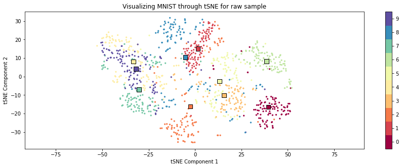

```python
plt.scatter(xtest_tsne[:, 0], xtest_tsne[:, 1], s= 5, c=ytest_flat, cmap='Spectral')
plt.scatter(mean_tsne_0,mean_tsne_1,c=unames,cmap='Spectral',marker ="s", edgecolor ="black", s = 70)
plt.rcParams["figure.figsize"] = (15,5)
plt.gca().set_aspect('equal', 'datalim')
plt.colorbar(boundaries=np.arange(11)-0.5).set_ticks(np.arange(10))
plt.title('Visualizing MNIST through tSNE for raw sample', fontsize=12);
plt.xlabel('tSNE Component 1')
plt.ylabel('tSNE Component 2')
```

PCA and tSNE for first layer

```python
# Ref: https://stackoverflow.com/questions/41711190/keras-how-to-get-the-output-of-each-layer
layer_name = 'dense'
intermediate_layer_model = Model(inputs=baseline.input,
                                 outputs=baseline.get_layer(layer_name).output)
first_layer = intermediate_layer_model.predict(xtest_flat)
#xtest_flat = xtest_flat.reshape(xtest_flat.shape[0], -1)
```

```python
pca_dim_1 = PCA(n_components=2)
firstlayer_pca = pca_dim_1.fit_transform(first_layer)
```

```python
unames, id, count = np.unique(ytest_flat, return_inverse=True, return_counts=True)
sum_pca_0 = np.bincount(id, weights=firstlayer_pca[:, 0])
sum_pca_1= np.bincount(id, weights=firstlayer_pca[:, 1])
mean_pca_0 = sum_pca_0/count
mean_pca_1 = sum_pca_1 /count
```

The first layer outputs in PCA are little difficult to classify because there are some overlappings, but still you can see different clusters overall.

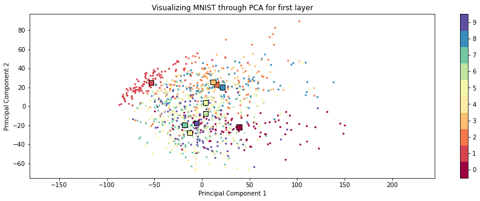

```python
plt.scatter(firstlayer_pca[:, 0], firstlayer_pca[:, 1], s= 5, c=ytest_flat, cmap='Spectral')
plt.scatter(mean_pca_0,mean_pca_1,c=unames,cmap='Spectral',marker ="s", edgecolor ="black", s = 70)
plt.rcParams["figure.figsize"] = (15,5)
plt.gca().set_aspect('equal', 'datalim')
plt.colorbar(boundaries=np.arange(11)-0.5).set_ticks(np.arange(10))
plt.title('Visualizing MNIST through PCA for first layer', fontsize=12);
plt.xlabel('Principal Component 1')
plt.ylabel('Principal Component 2')
```

```python
tsne = TSNE(n_components=2, random_state=0)
firstlayer_tsne= tsne.fit_transform(first_layer)
```

```python
unames, id, count = np.unique(ytest_flat, return_inverse=True, return_counts=True)
sum_tsne_0 = np.bincount(id, weights=firstlayer_tsne[:, 0])
sum_tsne_1= np.bincount(id, weights=firstlayer_tsne[:, 1])
mean_tsne_0 = sum_tsne_0/count
mean_tsne_1 = sum_tsne_1 /count
```

The first layer outputs in tSNE are better to classify as compared t0 the PCA, the clusters are clearly seperable, there does exist some overlapping though.

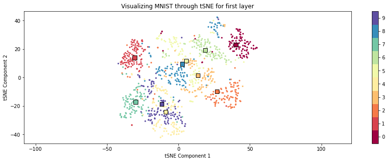

```python
plt.scatter(firstlayer_tsne[:, 0], firstlayer_tsne[:, 1], s= 5, c=ytest_flat, cmap='Spectral')
plt.scatter(mean_tsne_0,mean_tsne_1,c=unames,cmap='Spectral',marker ="s", edgecolor ="black", s = 70)
plt.rcParams["figure.figsize"] = (15,5)
plt.gca().set_aspect('equal', 'datalim')
plt.colorbar(boundaries=np.arange(11)-0.5).set_ticks(np.arange(10))
plt.title('Visualizing MNIST through tSNE for first layer', fontsize=12);
plt.xlabel('tSNE Component 1')
plt.ylabel('tSNE Component 2')
```

PCA and tSNE Second Layer

```python
# Ref: https://stackoverflow.com/questions/41711190/keras-how-to-get-the-output-of-each-layer
layer_name = 'dense_1'
intermediate_layer_model = Model(inputs=baseline.input,
                                 outputs=baseline.get_layer(layer_name).output)
second_layer = intermediate_layer_model.predict(xtest_flat)
```

```python
pca_dim_2 = PCA(n_components=2)
secondlayer_pca = pca_dim_2.fit_transform(second_layer)
```

```python
unames, id, count = np.unique(ytest_flat, return_inverse=True, return_counts=True)
sum_pca_0 = np.bincount(id, weights=secondlayer_pca[:, 0])
sum_pca_1= np.bincount(id, weights=secondlayer_pca[:, 1])
mean_pca_0 = sum_pca_0/count
mean_pca_1 = sum_pca_1 /count
```

As compared to the previous plots for PCA, this one has clusters closer to each other, making the seperability little difficult.

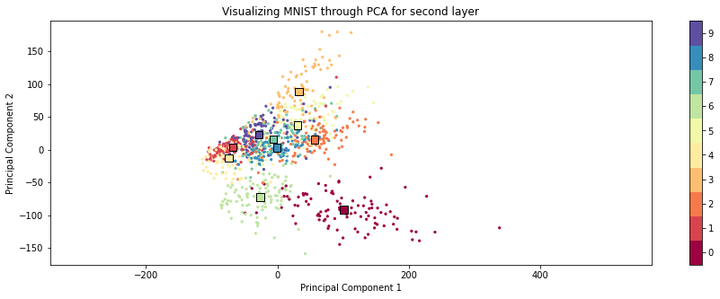

```python
plt.scatter(secondlayer_pca[:, 0], secondlayer_pca[:, 1], s= 5, c=ytest_flat, cmap='Spectral')
plt.scatter(mean_pca_0,mean_pca_1,c=unames,cmap='Spectral',marker ="s", edgecolor ="black", s = 70)
plt.rcParams["figure.figsize"] = (15,5)
plt.gca().set_aspect('equal', 'datalim')
plt.colorbar(boundaries=np.arange(11)-0.5).set_ticks(np.arange(10))
plt.title('Visualizing MNIST through PCA for second layer', fontsize=12);
plt.xlabel('Principal Component 1')
plt.ylabel('Principal Component 2')
```

```python
tsne = TSNE(n_components=2, random_state=0)
secondlayer_tsne= tsne.fit_transform(second_layer)
```

```python
unames, id, count = np.unique(ytest_flat, return_inverse=True, return_counts=True)
sum_tsne_0 = np.bincount(id, weights=secondlayer_tsne[:, 0])
sum_tsne_1= np.bincount(id, weights=secondlayer_tsne[:, 1])
mean_tsne_0 = sum_tsne_0/count
mean_tsne_1 = sum_tsne_1 /count
```

This plot for second layer output in tSNE gives perfectly seperable clusters, which are clearly distinguishable.

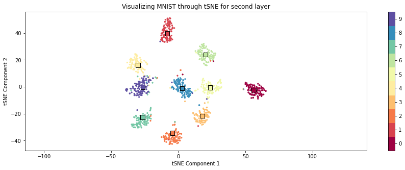

```python
plt.scatter(secondlayer_tsne[:, 0], secondlayer_tsne[:, 1], s= 5, c=ytest_flat, cmap='Spectral')
plt.scatter(mean_tsne_0,mean_tsne_1,c=unames,cmap='Spectral',marker ="s", edgecolor ="black", s = 70)
plt.rcParams["figure.figsize"] = (15,5)
plt.gca().set_aspect('equal', 'datalim')
plt.colorbar(boundaries=np.arange(11)-0.5).set_ticks(np.arange(10))
plt.title('Visualizing MNIST through tSNE for second layer', fontsize=12);
plt.xlabel('tSNE Component 1')
plt.ylabel('tSNE Component 2')
```

PCA and tSNE for third layer

```python
# Ref: https://stackoverflow.com/questions/41711190/keras-how-to-get-the-output-of-each-layer
layer_name = 'dense_2'
intermediate_layer_model = Model(inputs=baseline.input,
                                 outputs=baseline.get_layer(layer_name).output)
third_layer = intermediate_layer_model.predict(xtest_flat)
```

```python
pca_dim_3 = PCA(n_components=2)
thirdlayer_pca = pca_dim_3.fit_transform(third_layer)
```

```python
unames, id, count = np.unique(ytest_flat, return_inverse=True, return_counts=True)
sum_pca_0 = np.bincount(id, weights=thirdlayer_pca[:, 0])
sum_pca_1= np.bincount(id, weights=thirdlayer_pca[:, 1])
mean_pca_0 = sum_pca_0/count
mean_pca_1 = sum_pca_1 /count
```

For this plot too, the clusters are closer to each other making the seperability difficult.

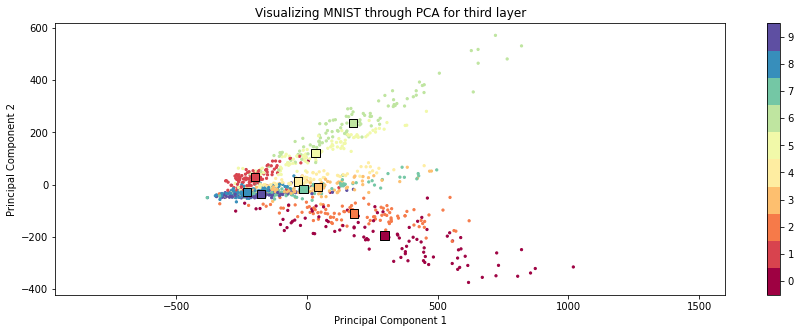

```python
plt.scatter(thirdlayer_pca[:, 0], thirdlayer_pca[:, 1], s= 5, c=ytest_flat, cmap='Spectral')
plt.scatter(mean_pca_0,mean_pca_1,c=unames,cmap='Spectral',marker ="s", edgecolor ="black", s = 70)
plt.rcParams["figure.figsize"] = (15,5)
plt.gca().set_aspect('equal', 'datalim')
plt.colorbar(boundaries=np.arange(11)-0.5).set_ticks(np.arange(10))
plt.title('Visualizing MNIST through PCA for third layer', fontsize=12);
plt.xlabel('Principal Component 1')
plt.ylabel('Principal Component 2')
```

```python
tsne = TSNE(n_components=2, random_state=0)
thirdlayer_tsne = tsne.fit_transform(third_layer)
```

```python
unames, id, count = np.unique(ytest_flat, return_inverse=True, return_counts=True)
sum_tsne_0 = np.bincount(id, weights=thirdlayer_tsne[:, 0])
sum_tsne_1= np.bincount(id, weights=thirdlayer_tsne[:, 1])
mean_tsne_0 = sum_tsne_0/count
mean_tsne_1 = sum_tsne_1 /count
```

This plot for third layer output in tSNE gives perfectly seperable clusters, which are clearly distinguishable.

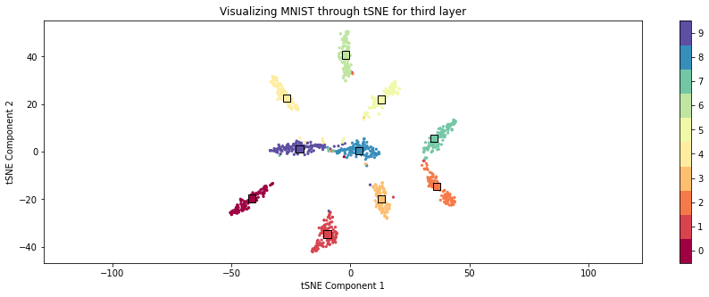

```python
plt.scatter(thirdlayer_tsne[:, 0], thirdlayer_tsne[:, 1], s= 5, c=ytest_flat, cmap='Spectral')
plt.scatter(mean_tsne_0,mean_tsne_1,c=unames,cmap='Spectral',marker ="s", edgecolor ="black", s = 70)
plt.rcParams["figure.figsize"] = (15,5)
plt.gca().set_aspect('equal', 'datalim')
plt.colorbar(boundaries=np.arange(11)-0.5).set_ticks(np.arange(10))
plt.title('Visualizing MNIST through tSNE for third layer', fontsize=12);
plt.xlabel('tSNE Component 1')
plt.ylabel('tSNE Component 2')
```

PCA and tSNE for forth layer

```python
# Ref: https://stackoverflow.com/questions/41711190/keras-how-to-get-the-output-of-each-layer
layer_name = 'dense_3'
intermediate_layer_model = Model(inputs=baseline.input,
                                 outputs=baseline.get_layer(layer_name).output)
forth_layer = intermediate_layer_model.predict(xtest_flat)
```

```python
pca_dim_4 = PCA(n_components=2)
forthlayer_pca = pca_dim_4.fit_transform(forth_layer)
```

```python
unames, id, count = np.unique(ytest_flat, return_inverse=True, return_counts=True)
sum_pca_0 = np.bincount(id, weights=forthlayer_pca[:, 0])
sum_pca_1= np.bincount(id, weights=forthlayer_pca[:, 1])
mean_pca_0 = sum_pca_0/count
mean_pca_1 = sum_pca_1 /count
```

As compared to the previous 2 plots the cluster overlappting has reduced and there is seperability visible, although it is not completly seperable.

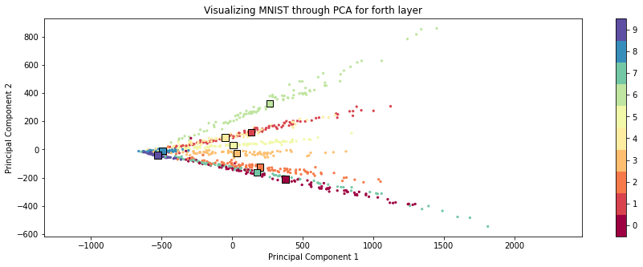

```python
plt.scatter(forthlayer_pca[:, 0], forthlayer_pca[:, 1], s= 5, c=ytest_flat, cmap='Spectral')
plt.scatter(mean_pca_0,mean_pca_1,c=unames,cmap='Spectral',marker ="s", edgecolor ="black", s = 70)
plt.rcParams["figure.figsize"] = (15,5)
plt.gca().set_aspect('equal', 'datalim')
plt.colorbar(boundaries=np.arange(11)-0.5).set_ticks(np.arange(10))
plt.title('Visualizing MNIST through PCA for forth layer', fontsize=12);
plt.xlabel('Principal Component 1')
plt.ylabel('Principal Component 2')
```

```python
tsne = TSNE(n_components=2, random_state=0)
forthlayer_tsne = tsne.fit_transform(forth_layer)
```

```python
unames, id, count = np.unique(ytest_flat, return_inverse=True, return_counts=True)
sum_tsne_0 = np.bincount(id, weights=forthlayer_tsne[:, 0])
sum_tsne_1= np.bincount(id, weights=forthlayer_tsne[:, 1])
mean_tsne_0 = sum_tsne_0/count
mean_tsne_1 = sum_tsne_1 /count
```

Here, the sperablitly is visible and is pretty much clear, just for some parts it is overlapping, other than that it is perfect.

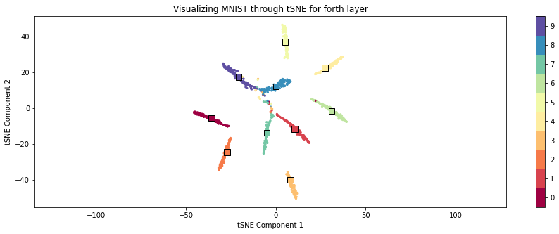

```python
plt.scatter(forthlayer_tsne[:, 0], forthlayer_tsne[:, 1], s= 5, c=ytest_flat, cmap='Spectral')
plt.scatter(mean_tsne_0,mean_tsne_1,c=unames,cmap='Spectral',marker ="s", edgecolor ="black", s = 70)
plt.rcParams["figure.figsize"] = (15,5)
plt.gca().set_aspect('equal', 'datalim')
plt.colorbar(boundaries = np.arange(11)-0.5).set_ticks(np.arange(10))
plt.title('Visualizing MNIST through tSNE for forth layer', fontsize=12);
plt.xlabel('tSNE Component 1')
plt.ylabel('tSNE Component 2')
```

PCA for fifth layer

```python
# Ref: https://stackoverflow.com/questions/41711190/keras-how-to-get-the-output-of-each-layer
layer_name = 'dense_4'
intermediate_layer_model = Model(inputs=baseline.input,
                                 outputs=baseline.get_layer(layer_name).output)
fifth_layer = intermediate_layer_model.predict(xtest_flat)
```

```python
pca_dim_5 = PCA(n_components=2,whiten=True)
fifthlayer_pca = pca_dim_5.fit_transform(fifth_layer)
```

```python
unames, id, count = np.unique(ytest_flat, return_inverse=True, return_counts=True)
sum_pca_0 = np.bincount(id, weights=fifthlayer_pca[:, 0])
sum_pca_1= np.bincount(id, weights=fifthlayer_pca[:, 1])
mean_pca_0 = sum_pca_0/count
mean_pca_1 = sum_pca_1 /count
```

For this layer, the seprablity is difficult and can be seen only for specific clusters, the rest are overlapping.

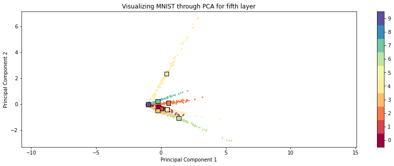

```python
plt.scatter(fifthlayer_pca[:, 0], fifthlayer_pca[:, 1], s= 5, c=ytest_flat, cmap='Spectral')
plt.scatter(mean_pca_0,mean_pca_1,c=unames,cmap='Spectral',marker ="s", edgecolor ="black", s = 70)
plt.rcParams["figure.figsize"] = (15,5)
plt.gca().set_aspect('equal', 'datalim')
plt.colorbar(boundaries=np.arange(11)-0.5).set_ticks(np.arange(10))
plt.title('Visualizing MNIST through PCA for fifth layer', fontsize=12);
plt.xlabel('Principal Component 1')
plt.ylabel('Principal Component 2')
```

```python
tsne = TSNE(n_components=2, random_state=0)
fifthlayer_tsne = tsne.fit_transform(fifth_layer)
```

```python
unames, id, count = np.unique(ytest_flat, return_inverse=True, return_counts=True)
sum_tsne_0 = np.bincount(id, weights=fifthlayer_tsne[:, 0])
sum_tsne_1= np.bincount(id, weights=fifthlayer_tsne[:, 1])
mean_tsne_0 = sum_tsne_0/count
mean_tsne_1 = sum_tsne_1 /count
```

tSNE again gives better seperability and the clusters are clearly visible, except for a few overlaps.

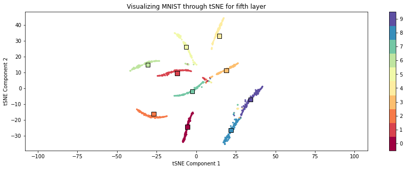

```python
plt.scatter(fifthlayer_tsne[:, 0], fifthlayer_tsne[:, 1], s= 5, c=ytest_flat, cmap='Spectral')
plt.scatter(mean_tsne_0,mean_tsne_1,c=unames,cmap='Spectral',marker ="s", edgecolor ="black", s = 70)
plt.rcParams["figure.figsize"] = (15,5)
plt.gca().set_aspect('equal', 'datalim')
plt.colorbar(boundaries = np.arange(11)-0.5).set_ticks(np.arange(10))
plt.title('Visualizing MNIST through tSNE for fifth layer', fontsize=12);
plt.xlabel('tSNE Component 1')
plt.ylabel('tSNE Component 2')
```

**Part 2**

```python
(xtrain, ytrain), (xtest,ytest) = mnist.load_data()
xtrain, xtest = xtrain/255, xtest/255
```

```python
initializer = tf.keras.initializers.RandomNormal(mean=0, stddev=0.01)
model1 = tf.keras.models.Sequential([
          tf.keras.layers.Flatten(input_shape=(28,28)),
          tf.keras.layers.Dense(512,activation='sigmoid',kernel_initializer=initializer),
          tf.keras.layers.Dense(512,activation='sigmoid'),
          tf.keras.layers.Dense(512,activation='sigmoid'),
          tf.keras.layers.Dense(512,activation='sigmoid'),
          tf.keras.layers.Dense(512,activation='sigmoid'),
          tf.keras.layers.Dense(10,activation='softmax')
 ])
```

SGD with Random Normal amd sigmoid activation

```python
optimizer1_sgd = tf.keras.optimizers.SGD(learning_rate=0.01)
model1.compile(optimizer=optimizer1_sgd,loss='sparse_categorical_crossentropy',metrics=['accuracy'])
```

```python
hist1_sgd = model1.fit(xtrain,ytrain,epochs=50,validation_data=(xtest, ytest))
```

```python
model1.evaluate(xtest,ytest)
```

```
[2.284395217895508, 0.17880000174045563]
```

```python
initializer = tf.keras.initializers.RandomNormal(mean=0, stddev=0.01)
model1 = tf.keras.models.Sequential([
          tf.keras.layers.Flatten(input_shape=(28,28)),
          tf.keras.layers.Dense(512,activation='sigmoid',kernel_initializer=initializer),
          tf.keras.layers.Dense(512,activation='sigmoid'),
          tf.keras.layers.Dense(512,activation='sigmoid'),
          tf.keras.layers.Dense(512,activation='sigmoid'),
          tf.keras.layers.Dense(512,activation='sigmoid'),
          tf.keras.layers.Dense(10,activation='softmax')
 ])
```

Adam with Random Normal amd sigmoid activation

```python
optimizer1_adam = tf.keras.optimizers.Adam()
model1.compile(optimizer=optimizer1_adam,loss='sparse_categorical_crossentropy',metrics=['accuracy'])
```

```python
hist1_adam = model1.fit(xtrain,ytrain,epochs=50,validation_data=(xtest, ytest))
```

```python
model1.evaluate(xtest,ytest)
```

```
[0.1484602689743042, 0.98089998960495]
```

```python
initializer = tf.keras.initializers.GlorotNormal()
model2 = tf.keras.models.Sequential([
          tf.keras.layers.Flatten(input_shape=(28,28)),
          tf.keras.layers.Dense(512,activation='sigmoid',kernel_initializer=initializer),
          tf.keras.layers.Dense(512,activation='sigmoid'),
          tf.keras.layers.Dense(512,activation='sigmoid'),
          tf.keras.layers.Dense(512,activation='sigmoid'),
          tf.keras.layers.Dense(512,activation='sigmoid'),
          tf.keras.layers.Dense(10,activation='softmax')
 ])
```

SGD with Xavier Normal amd sigmoid activation

```python
optimizer2_sgd = tf.keras.optimizers.SGD(learning_rate=0.01)
model2.compile(optimizer=optimizer2_sgd,loss='sparse_categorical_crossentropy',metrics=['accuracy'])
```

```python
hist2_sgd = model2.fit(xtrain,ytrain,epochs=50,validation_data=(xtest, ytest))
```

```python
model2.evaluate(xtest,ytest)
```

```
[0.49667954444885254, 0.8607000112533569]
```

```python
initializer = tf.keras.initializers.GlorotNormal()
model2 = tf.keras.models.Sequential([
          tf.keras.layers.Flatten(input_shape=(28,28)),
          tf.keras.layers.Dense(512,activation='sigmoid',kernel_initializer=initializer),
          tf.keras.layers.Dense(512,activation='sigmoid'),
          tf.keras.layers.Dense(512,activation='sigmoid'),
          tf.keras.layers.Dense(512,activation='sigmoid'),
          tf.keras.layers.Dense(512,activation='sigmoid'),
          tf.keras.layers.Dense(10,activation='softmax')
 ])
```

Adam with Xavier Normal amd sigmoid activation

```python
optimizer2_adam = tf.keras.optimizers.Adam()
model2.compile(optimizer=optimizer2_adam,loss='sparse_categorical_crossentropy',metrics=['accuracy'])
```

```python
hist2_adam = model2.fit(xtrain,ytrain,epochs=50,validation_data=(xtest, ytest))
```

```python
model2.evaluate(xtest,ytest)
```

```
[0.1274813711643219, 0.982200026512146]
```

```python
initializer = tf.keras.initializers.RandomNormal(mean=0, stddev=0.01)
model3 = tf.keras.models.Sequential([
          tf.keras.layers.Flatten(input_shape=(28,28)),
          tf.keras.layers.Dense(512,activation='relu',kernel_initializer=initializer),
          tf.keras.layers.Dense(512,activation='relu'),
          tf.keras.layers.Dense(512,activation='relu'),
          tf.keras.layers.Dense(512,activation='relu'),
          tf.keras.layers.Dense(512,activation='relu'),
          tf.keras.layers.Dense(10,activation='softmax')
 ])
```

SGD with Random Normal and Relu activation

```python
optimizer3_sgd = tf.keras.optimizers.SGD(learning_rate=0.01)
model3.compile(optimizer=optimizer3_sgd,loss='sparse_categorical_crossentropy',metrics=['accuracy'])
```

```python
hist3_sgd = model3.fit(xtrain,ytrain,epochs=50,validation_data=(xtest, ytest))
```

```python
model3.evaluate(xtest,ytest)
```

```
[0.08439742773771286, 0.9817000031471252]
```

```python
initializer = tf.keras.initializers.RandomNormal(mean=0, stddev=0.01)
model3 = tf.keras.models.Sequential([
          tf.keras.layers.Flatten(input_shape=(28,28)),
          tf.keras.layers.Dense(512,activation='relu',kernel_initializer=initializer),
          tf.keras.layers.Dense(512,activation='relu'),
          tf.keras.layers.Dense(512,activation='relu'),
          tf.keras.layers.Dense(512,activation='relu'),
          tf.keras.layers.Dense(512,activation='relu'),
          tf.keras.layers.Dense(10,activation='softmax')
 ])
```

Adam with Random Normal and Relu activation

```python
optimizer3_adam = tf.keras.optimizers.Adam()
model3.compile(optimizer=optimizer3_adam,loss='sparse_categorical_crossentropy',metrics=['accuracy'])
```

```python
hist3_adam = model3.fit(xtrain,ytrain,epochs=50,validation_data=(xtest, ytest))
```

```python
model3.evaluate(xtest,ytest)
```

```
[0.2566221058368683, 0.9781000018119812]
```

```python
initializer = tf.keras.initializers.GlorotNormal()
model4 = tf.keras.models.Sequential([
          tf.keras.layers.Flatten(input_shape=(28,28)),
          tf.keras.layers.Dense(512,activation='relu',kernel_initializer=initializer),
          tf.keras.layers.Dense(512,activation='relu'),
          tf.keras.layers.Dense(512,activation='relu'),
          tf.keras.layers.Dense(512,activation='relu'),
          tf.keras.layers.Dense(512,activation='relu'),
          tf.keras.layers.Dense(10,activation='softmax')
 ])
```

SGD with Xavier Normal and Relu activation

```python
optimizer4_sgd = tf.keras.optimizers.SGD(learning_rate=0.01)
model4.compile(optimizer=optimizer4_sgd,loss='sparse_categorical_crossentropy',metrics=['accuracy'])
```

```python
hist4_sgd = model4.fit(xtrain,ytrain,epochs=50,validation_data=(xtest, ytest))
```

```python
model4.evaluate(xtest,ytest)
```

```
[0.09310168027877808, 0.98089998960495]
```

```python
initializer = tf.keras.initializers.GlorotNormal()
model4 = tf.keras.models.Sequential([
          tf.keras.layers.Flatten(input_shape=(28,28)),
          tf.keras.layers.Dense(512,activation='relu',kernel_initializer=initializer),
          tf.keras.layers.Dense(512,activation='relu'),
          tf.keras.layers.Dense(512,activation='relu'),
          tf.keras.layers.Dense(512,activation='relu'),
          tf.keras.layers.Dense(512,activation='relu'),
          tf.keras.layers.Dense(10,activation='softmax')
 ])
```

Adam with Random Xavier and Relu activation

```python
optimizer4_adam = tf.keras.optimizers.Adam()
model4.compile(optimizer=optimizer4_adam,loss='sparse_categorical_crossentropy',metrics=['accuracy'])
```

```python
hist4_adam = model4.fit(xtrain,ytrain,epochs=50,validation_data=(xtest, ytest))
```

```python
model4.evaluate(xtest,ytest)
```

```
[0.2657627463340759, 0.983299970626831]
```

```python
initializer = tf.keras.initializers.HeNormal()
model5 = tf.keras.models.Sequential([
          tf.keras.layers.Flatten(input_shape=(28,28)),
          tf.keras.layers.Dense(512,activation='relu',kernel_initializer=initializer),
          tf.keras.layers.Dense(512,activation='relu'),
          tf.keras.layers.Dense(512,activation='relu'),
          tf.keras.layers.Dense(512,activation='relu'),
          tf.keras.layers.Dense(512,activation='relu'),
          tf.keras.layers.Dense(10,activation='softmax')
 ])
```

SGD with He Normal and Relu activation

```python
optimizer5_sgd = tf.keras.optimizers.SGD(learning_rate=0.01)
model5.compile(optimizer=optimizer5_sgd,loss='sparse_categorical_crossentropy',metrics=['accuracy'])
```

```python
hist5_sgd = model5.fit(xtrain,ytrain,epochs=50,validation_data=(xtest, ytest))
```

```python
model5.evaluate(xtest,ytest)
```

```
[0.09240907430648804, 0.9799000024795532]
```

```python
initializer = tf.keras.initializers.HeNormal()
model5 = tf.keras.models.Sequential([
          tf.keras.layers.Flatten(input_shape=(28,28)),
          tf.keras.layers.Dense(512,activation='relu',kernel_initializer=initializer),
          tf.keras.layers.Dense(512,activation='relu'),
          tf.keras.layers.Dense(512,activation='relu'),
          tf.keras.layers.Dense(512,activation='relu'),
          tf.keras.layers.Dense(512,activation='relu'),
          tf.keras.layers.Dense(10,activation='softmax')
 ])
```

Adam with He Normal and Relu activation

```python
optimizer5_adam = tf.keras.optimizers.Adam()
model5.compile(optimizer=optimizer5_adam,loss='sparse_categorical_crossentropy',metrics=['accuracy'])
```

```python
hist5_adam = model5.fit(xtrain,ytrain,epochs=50,validation_data=(xtest, ytest))
```

```python
model5.evaluate(xtest,ytest)
```

```
[0.2709060609340668, 0.9812999963760376]
```

Replicating the model accuracy graph for SGD with 5 different models

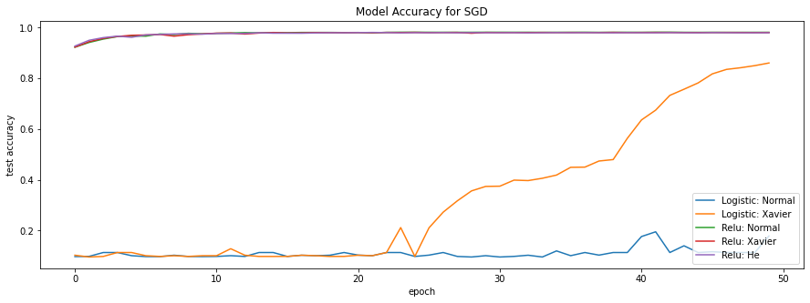

```python
plt.plot(hist1_sgd.history['val_accuracy'])
plt.plot(hist2_sgd.history['val_accuracy'])
plt.plot(hist3_sgd.history['val_accuracy'])
plt.plot(hist4_sgd.history['val_accuracy'])
plt.plot(hist5_sgd.history['val_accuracy'])
plt.title('Model Accuracy for SGD')
plt.ylabel('test accuracy')
plt.xlabel('epoch')
plt.legend(['Logistic: Normal','Logistic: Xavier','Relu: Normal','Relu: Xavier','Relu: He',], loc='lower right')
plt.show()
```

Replicating the model accuracy graph for Adam with 5 different models

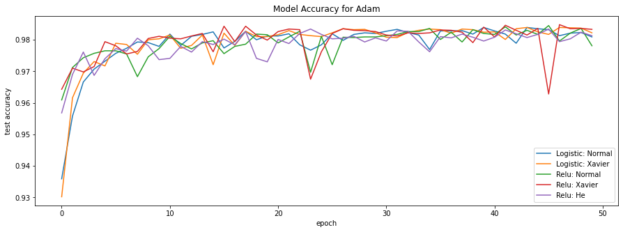

```python
plt.plot(hist1_adam.history['val_accuracy'])
plt.plot(hist2_adam.history['val_accuracy'])
plt.plot(hist3_adam.history['val_accuracy'])
plt.plot(hist4_adam.history['val_accuracy'])
plt.plot(hist5_adam.history['val_accuracy'])
plt.title('Model Accuracy for Adam')
plt.ylabel('test accuracy')
plt.xlabel('epoch')
plt.legend(['Logistic: Normal','Logistic: Xavier','Relu: Normal','Relu: Xavier','Relu: He',], loc='lower right')
plt.show()
```

**Part 3**

Activation function: the logistic sigmoid function; initialization: Xavier initializer; no dropout

```python
initializer = tf.keras.initializers.GlorotNormal()
model_1 = tf.keras.models.Sequential([
          tf.keras.layers.Flatten(input_shape=(28,28)),
          tf.keras.layers.Dense(1024,activation='sigmoid',kernel_initializer=initializer),
          tf.keras.layers.Dense(1024,activation='sigmoid'),
          tf.keras.layers.Dense(1024,activation='sigmoid'),
          tf.keras.layers.Dense(1024,activation='sigmoid'),
          tf.keras.layers.Dense(1024,activation='sigmoid'),
          tf.keras.layers.Dense(10,activation='softmax')
 ])
```

```python
optimizer = tf.keras.optimizers.Adam(lr=0.0001)
model_1.compile(optimizer=optimizer,loss='sparse_categorical_crossentropy',metrics=['accuracy'])
```

```python
hist_1 = model_1.fit(xtrain,ytrain,epochs=300,validation_data=(xtest, ytest))
```

```python
model_1.evaluate(xtest,ytest)
```

```
[0.22385063767433167, 0.9824000000953674]
```

Activation function: the logistic sigmoid function; initialization: Xavier initializer; with dropout rate: 0.2 for the ﬁrst layer and 0.5 for the other hidden layers

```python
initializer = tf.keras.initializers.GlorotNormal()
model_2 = tf.keras.models.Sequential([
          tf.keras.layers.Flatten(input_shape=(28,28)),
          tf.keras.layers.Dense(1024,activation='sigmoid',kernel_initializer=initializer),
          tf.keras.layers.Dropout(0.2),
          tf.keras.layers.Dense(1024,activation='sigmoid'),
          tf.keras.layers.Dropout(0.5),
          tf.keras.layers.Dense(1024,activation='sigmoid'),
          tf.keras.layers.Dropout(0.5),
          tf.keras.layers.Dense(1024,activation='sigmoid'),
          tf.keras.layers.Dropout(0.5),
          tf.keras.layers.Dense(1024,activation='sigmoid'),
          tf.keras.layers.Dropout(0.5),
          tf.keras.layers.Dense(10,activation='softmax')
 ])
```

```python
optimizer = tf.keras.optimizers.Adam(learning_rate=0.0001)
model_2.compile(optimizer=optimizer,loss='sparse_categorical_crossentropy',metrics=['accuracy'])
```

```python
hist_2 = model_2.fit(xtrain,ytrain,epochs=300,validation_data=(xtest, ytest))
```

```python
model_2.evaluate(xtest,ytest)
```

```
[0.14816699922084808, 0.9842000007629395]
```

As you can see from the plot for Logistic with and wtihout dropout, the test loss is less for dropout as compared to without dropout. Also, the train loss suffers more in droppout since it is subjected to different feed forwards at every epoch which makes the model more robust.

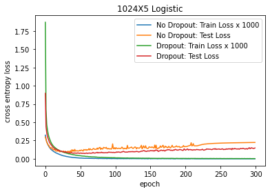

```python
plt.plot(hist_1.history['loss'])
plt.plot(hist_1.history['val_loss'])
plt.plot(hist_2.history['loss'])
plt.plot(hist_2.history['val_loss'])
plt.title('1024X5 Logistic')
plt.ylabel('cross entropy loss')
plt.xlabel('epoch')
plt.legend(['No Dropout: Train Loss x 1000', 'No Dropout: Test Loss','Dropout: Train Loss x 1000', 'Dropout: Test Loss'], loc='upper right')
plt.show()
```

Activation function: ReLU; initialization: Kaiming He’s initializer; no dropout

```python
initializer = tf.keras.initializers.HeNormal()
model_3 = tf.keras.models.Sequential([
          tf.keras.layers.Flatten(input_shape=(28,28)),
          tf.keras.layers.Dense(1024,activation='relu',kernel_initializer=initializer),
          tf.keras.layers.Dense(1024,activation='relu'),
          tf.keras.layers.Dense(1024,activation='relu'),
          tf.keras.layers.Dense(1024,activation='relu'),
          tf.keras.layers.Dense(1024,activation='relu'),
          tf.keras.layers.Dense(10,activation='softmax')
 ])
```

```python
optimizer = tf.keras.optimizers.Adam(learning_rate=0.0001)
model_3.compile(optimizer=optimizer,loss='sparse_categorical_crossentropy',metrics=['accuracy'])
```

```python
hist_3 = model_3.fit(xtrain,ytrain,epochs=300,validation_data=(xtest, ytest))
```

```python
model_3.evaluate(xtest,ytest)
```

```
[2.590029716491699, 0.9789000153541565]
```

Activation function: ReLU; initialization: Kaiming He’s initializer; with dropout rate: 0.2 for the ﬁrst layer and 0.5 for the other hidden layers

```python
initializer = tf.keras.initializers.HeNormal()
model_4 = tf.keras.models.Sequential([
          tf.keras.layers.Flatten(input_shape=(28,28)),
          tf.keras.layers.Dense(1024,activation='relu',kernel_initializer=initializer),
          tf.keras.layers.Dropout(0.2),
          tf.keras.layers.Dense(1024,activation='relu'),
          tf.keras.layers.Dropout(0.5),
          tf.keras.layers.Dense(1024,activation='relu'),
          tf.keras.layers.Dropout(0.5),
          tf.keras.layers.Dense(1024,activation='relu'),
          tf.keras.layers.Dropout(0.5),
          tf.keras.layers.Dense(1024,activation='relu'),
          tf.keras.layers.Dropout(0.5),
          tf.keras.layers.Dense(10,activation='softmax')
 ])
```

```python
optimizer = tf.keras.optimizers.Adam(learning_rate=0.0001)
model_4.compile(optimizer=optimizer,loss='sparse_categorical_crossentropy',metrics=['accuracy'])
```

```python
hist_4 = model_4.fit(xtrain,ytrain,epochs=300,validation_data=(xtest, ytest))
```

```python
model_4.evaluate(xtest,ytest)
```

```
[0.4313698709011078, 0.9858999848365784]
```

As you can see from the plot for Relu with and wtihout dropout, the test loss is less for dropout as compared to without dropout.

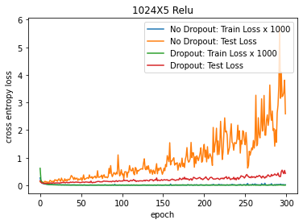

```python
plt.plot(hist_3.history['loss'])
plt.plot(hist_3.history['val_loss'])
plt.plot(hist_4.history['loss'])
plt.plot(hist_4.history['val_loss'])
plt.title('1024X5 Relu')
plt.ylabel('cross entropy loss')
plt.xlabel('epoch')
plt.legend(['No Dropout: Train Loss x 1000', 'No Dropout: Test Loss','Dropout: Train Loss x 1000', 'Dropout: Test Loss'], loc='upper right')
plt.show()
```

```python
%%shell
jupyter nbconvert --to html /DeepLearning_Assignment1_Ajinkya.ipynb
```

```
[NbConvertApp] Converting notebook /DeepLearning_Assignment1_Ajinkya.ipynb to html
[NbConvertApp] Writing 1737341 bytes to /DeepLearning_Assignment1_Ajinkya.html
```